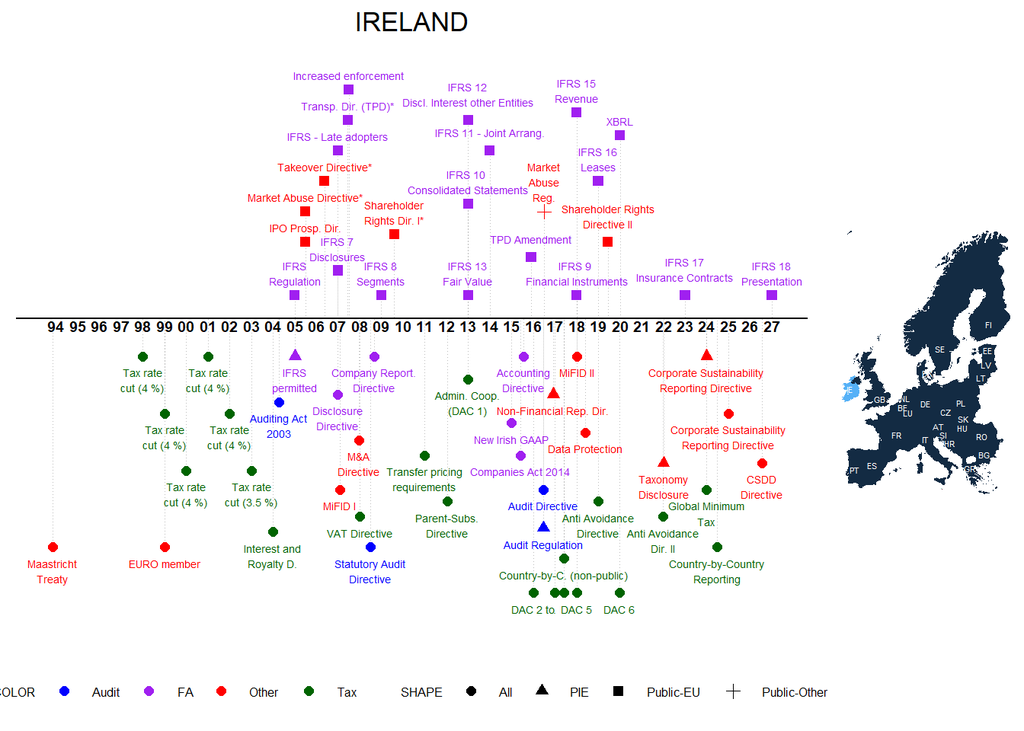

Notes: The graph depicts major regulatory changes that we identified via an extensive literature search, an online survey of mentioned authors, and other sources. Please note that the graph does not include all possible regulatory changes, e.g. minor revisions to local GAAP or tax rate changes below 3% are not included. The dates of EU Directives are based on the official transposition deadlines unless denoted with a *, in which case we included the entry-to-force date as identified in the literature. For more information, please go to [Labro and Pierk (2023)](http://www.eu-regulations.com/Labro_Pierk_2023.pdf). We kindly ask that you cite the paper if you use the information on this website in your research project. Do you have comments or see anything missing? Please email us!

## Regulations, Publications, Further Graphs

The tab ‘Regulations’ includes links to the regulations, gives short descriptions, and provides selective papers for further reading. If the regulation is a national transposition of an EU Directive, the link to the Directive is given. The tab ‘Number of Regulations’ shows graphically the number of regulations 8 years around the respective year (-4,-3,-2,-1,0,+1,+2,+3). The tab ‘Number of Categories” shows graphically the number of different categories 8 years around the respective year (-4,-3,-2,-1,0,+1,+2,+3). The tab ’Publications’ shows all publications that include the countries’ names and variations thereof in the title, abstract, or keywords. Similarly, the tab ‘SSRN’ shows papers of the SSRN Accouning Research Network that include the countries’ names and variations.

### Regulations

[output not shown]

[output cut: 55 more lines]

### Number of Regulations

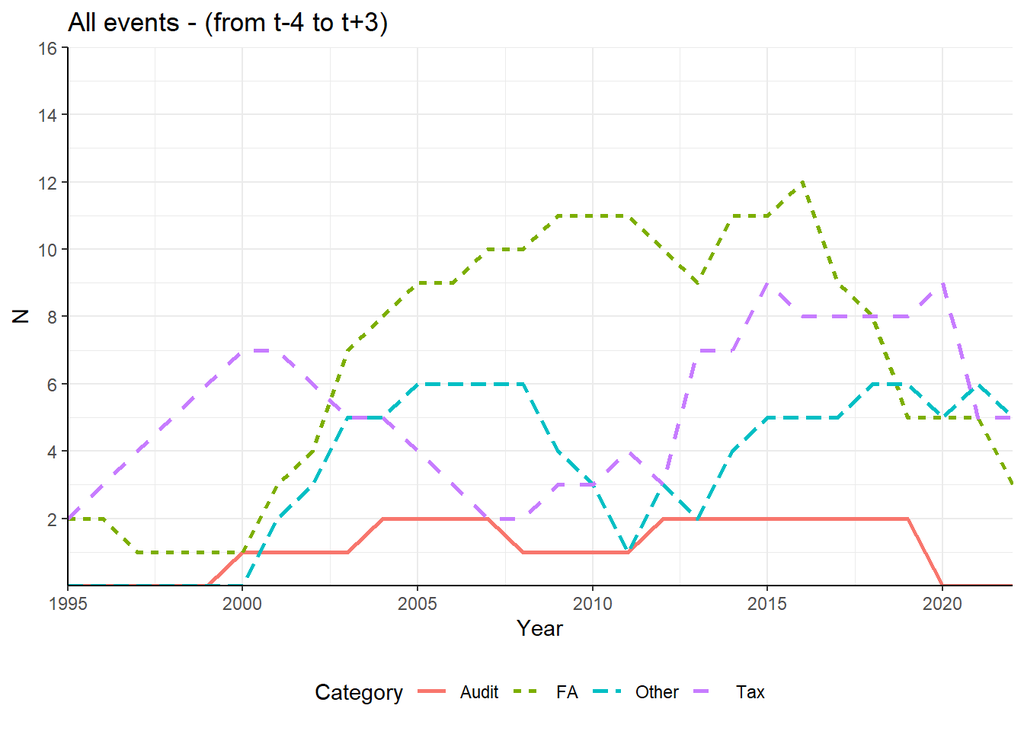

### Number of Categories

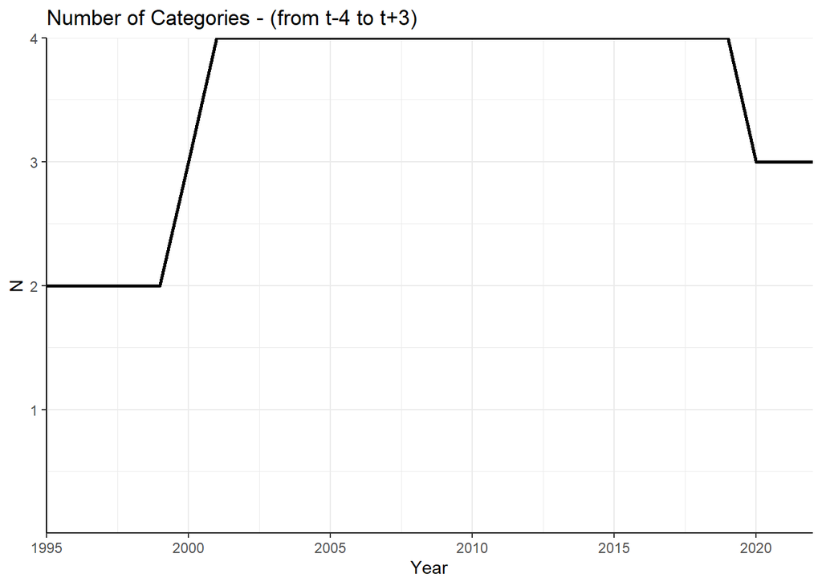

### Publications

|  | authors | title | year | journal |
| --- | --- | --- | --- | --- |
| 1 | Dunne N.J., Brennan N.M., Kirwan C.E. | impression management and big four auditors: scrutiny at a public inquiry | 2021 | Accounting, Organizations and Society |
| 2 | Key K., Healy M., Mulligan E. | closing the cultural intelligence skills gap in accounting students: an action research approach to cross-cultural teamwork | 2021 | British Accounting Review |
| 3 | O'Regan P., Killian S. | beyond professional closure: uncovering the hidden history of plain accountants | 2021 | Accounting, Organizations and Society |
| 4 | Arafat I., Dunne T., Ahmed A.H. | splitting accountability hairs: anomalies in the adaptation of ifrs for smes in the uk and ireland | 2020 | Accounting in Europe |
| 5 | Duff A., Hancock P., Marriott N. | the role and impact of professional accountancy associations on accounting education research: an international study | 2020 | British Accounting Review |
| 6 | Quinn M., Feeney O. | domestic waste policy in ireland – economization and the role of accounting | 2020 | Accounting, Auditing and Accountability Journal |
| 7 | Bedford D.S., Bisbe J., Sweeney B. | performance measurement systems as generators of cognitive conflict in ambidextrous firms | 2019 | Accounting, Organizations and Society |
| 8 | Kinsella S. | visualising economic crises using accounting models | 2019 | Accounting, Organizations and Society |
| 9 | Mulcahy M., Beck M., Carr M., Hourigan N. | novel approaches to the regulatory control of financial services providers: the importance of cultural context | 2019 | British Accounting Review |
| 10 | Chen N.X., Shevlin T. | “u.s. worldwide taxation and domestic mergers and acquisitions” a discussion✰ | 2018 | Journal of Accounting and Economics |

[output cut: 61 more lines]

### SSRN

|  | authors | title | Posted | Revised |
| --- | --- | --- | --- | --- |
| 1 | Andreas Seebeck and Devrimi Kaya | the power of words: an empirical analysis of the communicative value of extended auditor reports | 2021-10-01 |  |
| 2 | Spyridon Gkikopoulos, Edward Lee and Konstantinos Stathopoulos | does corporate tax avoidance affect firm productivity? | 2021-06-08 | 2022-01-24 |
| 3 | Novia (Xi) Chen, Terry J. Shevlin and Terry J. Shevlin | 'u.s. worldwide taxation and domestic mergers and acquisitions' a discussion | 2021-02-03 |  |
| 4 | Chris Evans and Cedric Sandford | capital gains tax – the unprincipled tax? | 2021-01-06 |  |
| 5 | John Malagila, Alaa Zalata, Collins G. Ntim and Ahmed A. Elamer | corporate governance and performance in sports organisations: the case of uk premier leagues | 2020-07-14 |  |
| 6 | Brando Maria Cremona and Maria Lucia Passador | shareholder activism today: did barbarians storm the gate? | 2020-07-14 | 2020-11-23 |
| 7 | Stephen Curtis | google's cost sharing arrangement: bride of frankenstein | 2022-02-03 |  |